## Reproducible Research: Peer Assessment 1

##### **Loading and preprocessing the data**

Show any code that is needed to

1. Load the data (i.e. read.csv())
2. Process/transform the data (if necessary) into a format suitable for your analysis

```r
  #Change the working directory to the folder where unzipped
  #file exists; On your system path would be different please ensure to
  #put the right path

  #setwd("C:/learn/data science/reproducible research/week2/assignment/RepData_PeerAssessment1")

  # load the unzipped activity data file in the dataframe named as ds
  ds_orignial<-read.csv(file="activity.csv",colClasses=c("integer","Date","integer"))
```

##### **What is mean total number of steps taken per day?**

For this part of the assignment, you can ignore the missing values in the dataset.

1. Calculate the total number of steps taken per day
2. If you do not understand the difference between a histogram and a barplot, research the difference between them. Make a histogram of the total number of steps taken each day

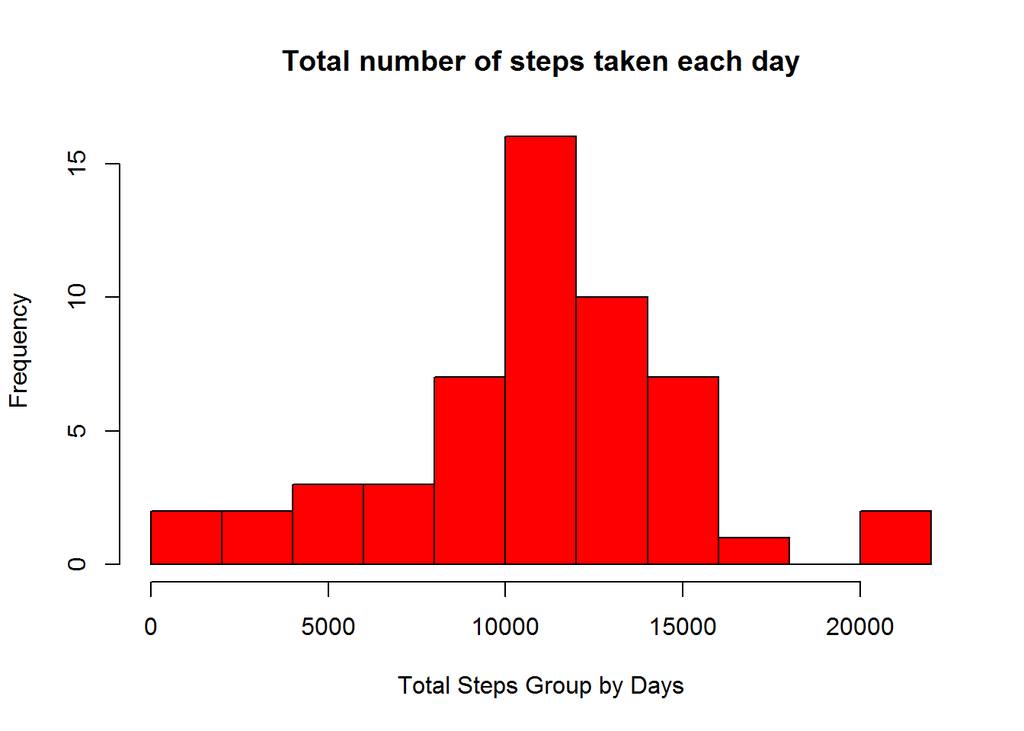

```r
#get rid of NA values
ds_omitted_na <-na.omit(ds_orignial)

#sum of steps grouped by Days
ds_steps_by_date<-aggregate(steps ~ date, ds_omitted_na, sum)

#generate histogram
hist(ds_steps_by_date$steps,breaks=10,col="red" , xlab = "Total Steps Group by Days", main="Total number of steps taken each day")
```

3. Calculate and report the mean and median of the total number of steps taken per day

```r
# get mean
mean(ds_steps_by_date$steps)
```

```
## [1] 10766.19
```

```r
# get median
median(ds_steps_by_date$steps)
```

```
## [1] 10765
```

##### **What is the average daily activity pattern?**

1. Make a time series plot (i.e. type = “l”) of the 5-minute interval (x-axis) and the average number of steps taken, averaged across all days (y-axis)

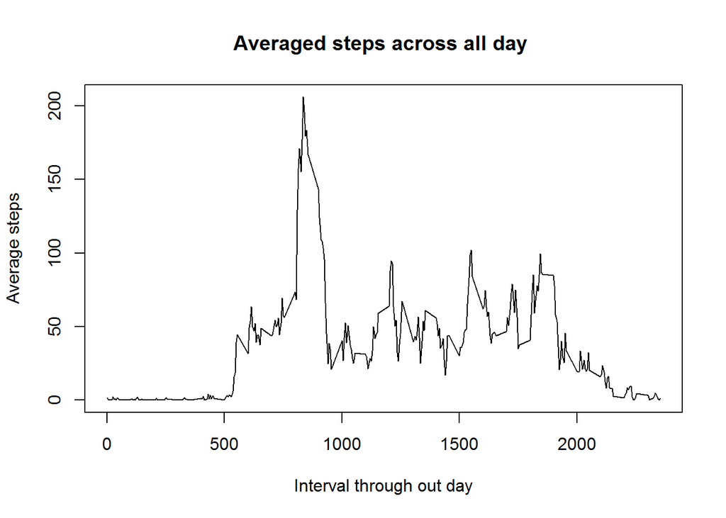

```r
#Average steps grouped by intervals
ds_steps_by_interval<-aggregate(steps ~ interval, ds_omitted_na, mean)

#create the plot
plot(ds_steps_by_interval$interval, ds_steps_by_interval$steps, type='l', ylab="Average steps", xlab="Interval through out day", main ="Averaged steps across all day ")
```

2. Which 5-minute interval, on average across all the days in the dataset, contains the maximum number of steps?

```r
  #Interval with maximum number of steps
  ds_steps_by_interval[which.max(ds_steps_by_interval$steps),]
```

```
##     interval    steps
## 104      835 206.1698
```

##### **Imputing missing values**

Note that there are a number of days/intervals where there are missing values (coded as NA). The presence of missing days may introduce bias into some calculations or summaries of the data.

1. Calculate and report the total number of missing values in the dataset (i.e. the total number of rows with NAs)

```r
  #get the count for rows where steps variable is NA
  nrow(ds_orignial[!complete.cases(ds_orignial),])
```

```
## [1] 2304
```

2. Devise a strategy for filling in all of the missing values in the dataset. The strategy does not need to be sophisticated. For example, you could use the mean/median for that day, or the mean for that 5-minute interval, etc.
3. Create a new dataset that is equal to the original dataset but with the missing data filled in.

Logic used for above task :

To fill the missing NA we will use the mean of specific interval as reported on the other day.

First we will locate the missing step value

Then we will find the mean value for that specific interval

After that we can put the value coming from above step into the missing Steps value spot.

```r
#create another dataframe copy the orginal values in it
ds_backfill<-ds_orignial

#loop throug each and every observation
for (i in 1:nrow(ds_backfill)){
#check if the step value is missing in it
    if (is.na(ds_backfill$steps[i])){
    #get the interval value for missing steps value
    interval_val <- ds_backfill$interval[i]

    #get the average steps belonging to the same interval
    #ds_steps_by_interval data frame was created in our earlier computation above
    ds_backfill$steps[i] <- ds_steps_by_interval$steps[ which(ds_steps_by_interval$interval == interval_val)]

  }
}
```

4. Make a histogram of the total number of steps taken each day and Calculate and report the mean and median total number of steps taken per day. Do these values differ from the estimates from the first part of the assignment? What is the impact of imputing missing data on the estimates of the total daily number of steps?

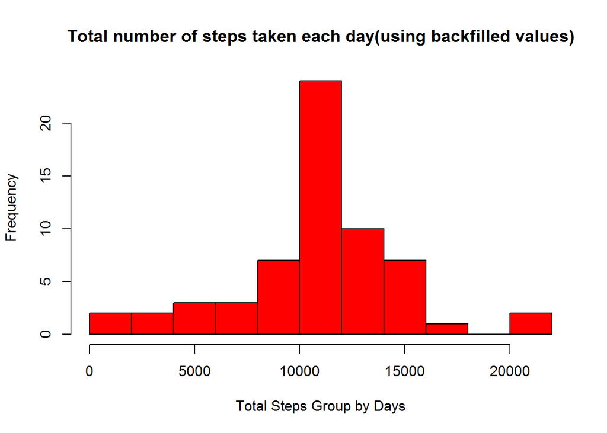

```r
  #sum of steps grouped by Days
  ds_backfill_steps_by_date <- aggregate(steps ~ date, ds_backfill, sum)



  #generate histogram with the backfilled values
  hist(ds_backfill_steps_by_date$steps,breaks=10,col="red" , xlab = "Total Steps Group by Days", main="Total number of steps taken each day(using backfilled values)")
```

```r
  #checking for the impact of backfilling the step values on means and median

  if (mean(ds_backfill_steps_by_date$steps)!=mean(ds_steps_by_date$steps))
    print("mean changed due to backfilling")
  if (median(ds_backfill_steps_by_date$steps)!=median(ds_steps_by_date$steps))
    print("median changed due to backfilling")
```

```
## [1] "median changed due to backfilling"
```

##### **Are there differences in activity patterns between weekdays and weekends?**

For this part the weekdays() function may be of some help here. Use the dataset with the filled-in missing values for this part.

1. Create a new factor variable in the dataset with two levels - “weekday” and “weekend” indicating whether a given date is a weekday or weekend day.
2. Make a panel plot containing a time series plot (i.e. type = “l”) of the 5-minute interval (x-axis) and the average number of steps taken, averaged across all weekday days or weekend days (y-axis). See the README file in the GitHub repository to see an example of what this plot should look like using simulated data.

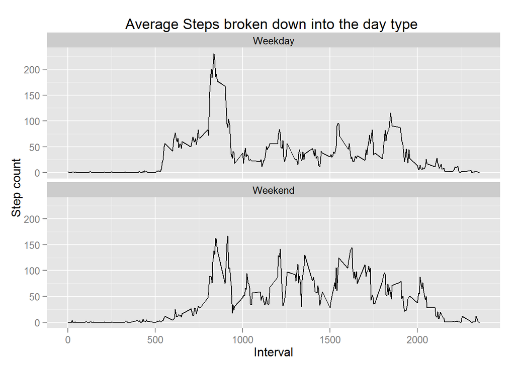

```r
# initalize the data frame
ds_day_factor <-ds_backfill

#check for the day type and store it in a seprate column
ds_day_factor$day_type<- ifelse ((weekdays(ds_day_factor$date)=="Saturday" | weekdays(ds_day_factor$date)=="Sunday" ), c("Weekend") ,   c("Weekday"))

# factor the values by day type
ds_day_factor$day_type<-as.factor(ds_day_factor$day_type)

#find out the mean
ds_steps_by_interval_day_type<-aggregate(steps ~ interval + day_type, ds_day_factor, mean)

#load ggplot
library(ggplot2)
#draw the plot
qplot(interval, steps, data=ds_steps_by_interval_day_type, geom=c("line"), xlab="Interval",  ylab="Step count", main="Average Steps broken down into the day type ") + facet_wrap(~ day_type, ncol=1)
```